# R Notebook

This file will take you through recreating the figures presented in the manuscript. Note that some of the figures went through additional edits in Illustrator for additional labelling!

# Preparation

## Load packages

```r
library(dplyr)
library(ggplot2)
library(forcats)
library(here)
library(deSolve)
library(crone)
library(optimParallel)
library(doParallel)
library(doRNG)
library(arrow)
library(stringr)
library(parallel)
library(ggpubr)
library(scales)
library(bayestestR)
library(purrr)
library(tidyr)
library(splines2)
library(splancs)
library(ggnewscale)
```

## load variables

```r
mc_single_dyn_cr_join.df_pr <- read_parquet(here("code_repository/data/mc_sinle_dyn_cr_join.parquet")) ## mc dynamics (single parameter variation) with only cr along with determinstic model cr
```

[output not shown]

#=================================# Illustrating spline optimization #=================================# # function to extract basis spline and plot

```r
plot_basis_spline <- function(par){
  # build dummy basis spline model
  dummy_cr.mod <- lm(rep(0, 101)  ~ splines2::bSpline(x = seq(0,100,1), degree = 3))

  # assign parameters
  dummy_cr.mod$coefficients <- par

  # get fit
  cr_fit <- predict(dummy_cr.mod, newdata = data.frame(seq(0,100,1)))

  # get basis spline database
  mod_bs <- dummy_cr.mod$model$`splines2::bSpline(x = seq(0, 100, 1), degree = 3)` %>% as.data.frame()

  # combine database
  max <- max(mod_bs$`1`,mod_bs$`2`,mod_bs$`3`, cr_fit,na.rm = T)
  mod_bs.p <- rbind(
    mod_bs %>% mutate(cue_range = seq(0,100,1), spline_value = ((`1`*par[2])+par[1])/max,fit = cr_fit/max, label = c("Column 1")),
    mod_bs %>% mutate(cue_range = seq(0,100,1), spline_value = ((`2`*par[3])+par[1])/max,fit = cr_fit/max, label = c("Column 2")),
    mod_bs %>% mutate(cue_range = seq(0,100,1), spline_value = ((`3`*par[4])+par[1])/max,fit = cr_fit/max, label = c("Column 3"))

    )


 # mod_bs.p <- mod_bs %>%
   # mutate(
   #   cue_range = seq(0,100,1),
   #   first_spline = ((`1`*par[2])+par[1])/max,
   #    second_spline = ((`2`*par[3])+par[1])/max,
    #   third_spline = ((`3`*par[4])+par[1])/max,
   #   fit = cr_fit/max
     #      )

  # plot
 # ggplot(mod_bs.p) +
  #  geom_line(aes(x = cue_range, y = fit), color = "Black") +
  #  geom_line(aes(x = cue_range, y = first_spline, color = "Column 1"), linetype = "dashed") +
  ##  geom_line(aes(x = cue_range, y = second_spline, color = "Column 2"), linetype = "dotted") +
  #  geom_line(aes(x = cue_range, y = third_spline, color = "Column 3"), linetype = "dotdash") +
  #  theme_bw() +
   ## labs(x = "Cue range", y = "Transmission investment", linetype = "Basis matrix", color = "Basis matrix") +
   # theme(
  # #     axis.text.x=element_blank(),
   #     axis.ticks.x=element_blank(),
  #      axis.text.y=element_blank(),
    #    axis.ticks.y=element_blank(),
     #   panel.grid.major = element_blank(), panel.grid.minor = element_blank())

  ggplot(mod_bs.p) +
    geom_line(aes(x = cue_range, y = fit), color = "Black") +
    geom_line(aes(x = cue_range, y = spline_value, color = label, linetype = label)) +
    theme_bw() +
    labs(x = "Cue range", y = "Transmission investment", linetype = "Basis matrix", color = "Basis matrix") +
    scale_linetype_manual(values = c("dashed", "dotted", "dotdash")) +
    theme(
       axis.text.x=element_blank(),
        axis.ticks.x=element_blank(),
       axis.text.y=element_blank(),
       axis.ticks.y=element_blank(),
       panel.grid.major = element_blank(), panel.grid.minor = element_blank())
}
```

# plot for multiple parameters

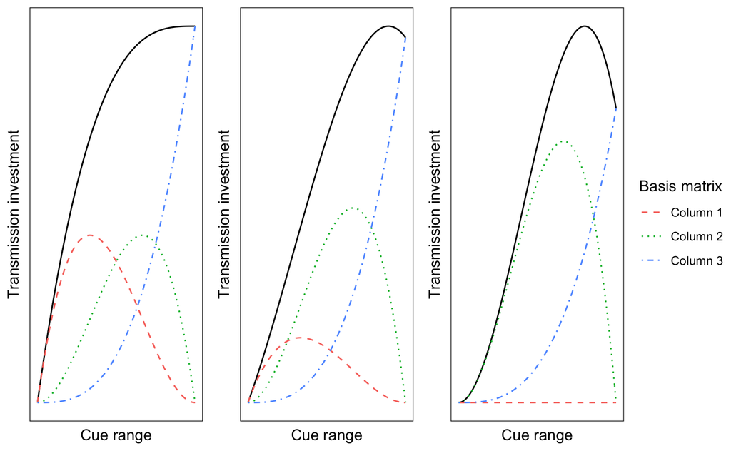

#=================================# # Cue perception mediates fitness #=================================# #———— A. conversion rate dynamics and fitness values ————# ## function for dynamics generation

```r
# function for getting single cue infection dynamics
get_si_dyn <- function(df){
  ## processing model input
  par <- c(df$var1, df$var2, df$var3, df$var4) ## parameters
  cue <- df$cue ## cue choice
  log <- ifelse(df$log=="log", "log10", "none") ## log or not
  cue_range <- seq(df$low, df$high, by = df$by) ## cue range
  id <- df$id ## id

  ## get dynamics data
  dyn <- chabaudi_si_clean(
            parameters_cr = par,
            parameters = parameters_tsukushi,
            time_range = seq(0, 30, 0.001),
            cue = cue,
            cue_range = cue_range,
            log_cue = log,
            immunity = "tsukushi",
            solver = "vode",
            dyn = TRUE)

  # append id
  dyn2 <- cbind(dyn, id = rep(id, nrow(dyn)))

  # return results
 return(dyn2)
}
```

## run function to generate data

## get 30 day simulation data (not used for fitness but for plotting purposes)

```r
## get dynamics
si_opt.ls2 <- split(si_opt.df %>% filter(cue != "t"), seq(nrow(si_opt.df%>% filter(cue != "t"))))
si_dyn_30 <- mclapply(si_opt.ls2, get_si_dyn, mc.cores = 8)

## combine the dynamics file
si_dyn_30.df <- do.call(rbind, si_dyn_30)
si_dyn_30.df %>% group_by(id) %>% summarise(max_time = max(time))
```

| id | max_time |
| --- | --- |
| G_log | 30 |
| G_none | 30 |
| I_log | 30 |
| I_none | 30 |
| I+Ig_log | 30 |
| I+Ig_none | 30 |
| Ig_log | 30 |
| Ig_none | 30 |
| R_log | 30 |
| R_none | 30 |

```r
## save
write_parquet(si_dyn_30.df, here("code_repository/data/si_dyn_30.parquet"))
```

## process data to isolate conversion rate and pair them with fitness

```r
## keep only conversion rate from dynamics
si_dyn_cr.df <- si_dyn.df %>% filter(variable == "cr")

## left join with fitness values
si_dyn_cr_fitness.df <- si_dyn_cr.df %>%
  left_join(si_opt.df, by = "id")

## normalize fitness by dividing all values by the fitness values we get when cue = time
si_opt.df <- si_opt.df %>%
  mutate(fitness_norm = fitness_20 / si_opt.df[si_opt.df$cue == "t",]$fitness_20)
```

## plot

```r
## plot together
fitness_rank_cr.plt <- ggarrange(fitness_rank.plt, fitness_cr.plt, widths = c(1.2, 1), align = "h", common.legend = T,
                                 legend = "bottom")
```

```
Removed 11022 rows containing missing values (geom_raster).Removed 11022 rows containing missing values (geom_raster).
```

#———— B. Reaction norms ————# ## function to obtain the cue values sensed by parasites from dynamics datas

```r
get_rug <- function(df){
  ## process cue
  cue <- unique(df$cue)

  ## if cue contains "+", we need to first split them up and add them into the final dataframe
   if(stringr::str_detect(cue, "\\+")){
    cue_split <- stringr::str_split(string = cue, pattern = "\\+", simplify = T)
    ## get the two cues
    cue_temp_1 <- cue_split[[1]]
    cue_temp_2 <- cue_split[[2]]
    ## filter dyn
    rug <- df %>%
      filter(variable == cue_temp_1 | variable == cue_temp_2) %>%
      dplyr::group_by(time) %>%
      dplyr::mutate(sum = sum(value, na.rm = T)) %>%
      select(time, value = sum, id)
  }

  # for cue with no addition, it is simply filtering for the values and returning it
  if(stringr::str_detect(cue, "\\+", negate = T)){
    rug <- df %>%
      dplyr::filter(variable == cue) %>%
      dplyr::select(time, value, id)}

  return(rug)
}
```

## run function to obtain cue values

```r
# join dynamics data with cue information
si_dyn_cue.df <- left_join(si_dyn.df, si_opt.df, by = "id")

# split based on individual labels
si_dyn_cue.ls <- si_dyn_cue.df %>% group_split(id)

# run function to get rug
si_rug <- mclapply(si_dyn_cue.ls, get_rug, mc.cores = 6)

# combine and save
si_rug.df <- do.call(rbind, si_rug)
write_parquet(si_rug.df, here("code_repository/data/si_rug.parquet"))
```

## function to obtain reaction norm

```r
get_si_rn <- function(df){
  ## read in the parameter sets
  par <- c(df$var1, df$var2, df$var3, df$var4)
  ## get cue range
  if(stringr::str_detect(df$log, "log", negate = T)){
     cue_range <- seq(log10(df$low+1), log10(df$high), length.out = 5000)
     cue_range<-10^cue_range
  }
  cue_range <- seq(df$low, df$high, length.out = 5000)

  ## nested function to convert parameter set into basis spline function
  rn <- par_to_df(par = par, cue_range = cue_range, max = df$high)

  # if parasite is sensing logged cue, we have to exponentiate it back so they are on the same scale!
  rn2 <- rn
  if(stringr::str_detect(df$log, "log")){rn2$cue_range <- 10^(rn2$cue_range)}

  # append label to reaction norm, dyn, and rug
  rn2 <- data.frame(rn2, id = df$id)

  return(rn2)
}
```

## run function to get reaction norms

```r
# split dataframe of optimized rcues
si_opt.ls <- split(si_opt.df, seq(nrow(si_opt.df)))

# run function
si_rn <- lapply(si_opt.ls, get_si_rn)

# bind together
si_rn.df <- do.call(rbind, si_rn)
write_parquet(si_rn.df, here("code_repository/data/si_rn.parquet"))
```

## preparing the dataset for plotting reaction norms and rugs

```r
## we are only plotting relevent ranges of the reaction norm, meaning that these are the cue values actually "sensed" by the parasites in an infection. We can use the rug dataframe to get a rough estimate of that
si_rug_lim.df <- si_rug.df %>%
  group_by(id)%>%
  summarise(min_temp = min(value, na.rm = T)*0.9,
         max_temp = max(value, na.rm = T)*1.1) %>% ## calculate min and max for each cue
  left_join(si_opt.df, by = "id") %>% ## join with si_opt so we can get the cmmon cue
  ungroup() %>%
  group_by(cue) %>%
  summarise(min = min(min_temp), max = max(max_temp))

## process reaction norm data to restrict range and get label
si_rn.df_p <- si_rn.df %>%
  left_join(select(si_opt.df, id, cue, log), by = "id") %>% ## get cue and log status from si_opt.df
  left_join(si_rug_lim.df, by = "cue") %>% ## via cue, get ranges we want to limit the rn to
  filter(cue_range <= max & cue_range >= min) %>% ## keep only cue values within range
  left_join(select(ez_label, id, cue_label), by = "id") %>% # get labels
  mutate(log2 = ifelse(log == "log", "log", "raw"))


## refactor to reorder the order at which the cues are presented
si_rn.df_p$cue_label <- factor(si_rn.df_p$cue_label,
                              levels = c("Asexual iRBC", "Sexual iRBC", "Total iRBC", "Gametocyte", "RBC"))

## split rug labels by none logged and logged
si_rug_cue.df <- si_rug.df %>%
  distinct(id, value) %>% ## cut down on number of datapoints. For each id, keep only distinct points
  left_join(select(si_opt.df, id, cue, log), by = "id") %>% ## get cue and log status from si_opt.df
  left_join(select(ez_label, id, cue_label), by = "id") ## get cue label for plotting

## refactor rug
si_rug_cue.df$cue_label <- factor(si_rug_cue.df$cue_label,
                              levels = c("Asexual iRBC", "Sexual iRBC", "Total iRBC", "Gametocyte", "RBC"))

### split
si_rug_cue.df_none <- si_rug_cue.df %>% filter(log == "none")
si_rug_cue.df_log <- si_rug_cue.df %>% filter(log == "log")
```

## plot reaction norms and associated rug plots

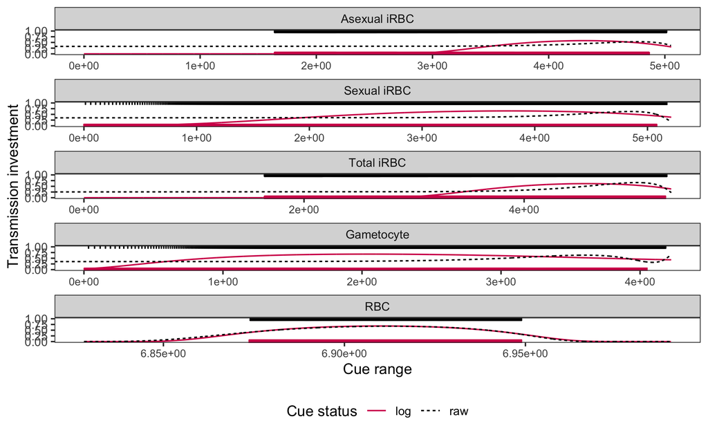

#———— Plotting fitness, dynamics, and rn together ————#

[output not shown]

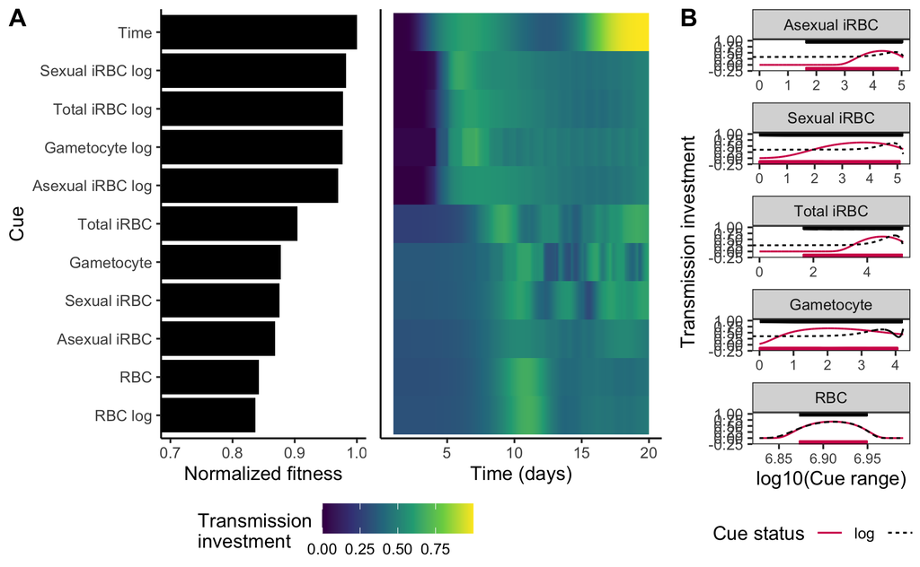

```r
ggarrange(fitness_rank_cr.plt, fitness_rn.plt, widths = c(2.7, 1), align = "h", ncol = 2, labels = c("A", "B"))
```

#=================================# # Dual cue fitness main figure #=================================# #————Relative ranking of dual cue vs single cue fitness———–# ## Prepare dual cue dataset

```r
## For the dual cue models, we optimized each cue combinations in 2 ways, one with L-BFGS-B with 0.5X9 starting point and another with DEoptim + L-FGBS-B. For each cue combination, we are going to pick the strategy that gave us the higher fitness
dual_cue_f_final.df <- dual_cue_f_init.df %>%
  select(id, id_b, label, label_b, fitness_init = fitness,
         par1_init = par1, par2_init = par2, par3_init = par3, par4_init = par4, par5_init = par5, par6_init = par6,
         par7_init = par7, par8_init = par8, par9_init = par9) %>%
  left_join(
  select(dual_cue_f_glb.df, id, id_b, label, label_b, fitness_glb = fitness,
         par1_glb = par1, par2_glb = par2, par3_glb = par3, par4_glb = par4, par5_glb = par5, par6_glb = par6,
         par7_glb = par7, par8_glb = par8, par9_glb = par9)) %>%
  left_join(
    select(dual_cue_f_lc.df,
         id, id_b, fitness_lc = fitness,
         par1_lc = par1, par2_lc = par2, par3_lc = par3, par4_lc = par4, par5_lc = par5, par6_lc = par6,
         par7_lc = par7, par8_lc = par8, par9_lc = par9), by = c("id", "id_b")
  ) %>% ## rename columns and join global and local optimization fitness dataframe
  group_by(id, id_b) %>%
  mutate(
    fitness = max(fitness_glb, fitness_lc, fitness_init),
    algo = case_when(
      fitness_glb == fitness ~ "glb",
      fitness_lc == fitness ~ "lc",
      fitness_init == fitness ~ "init"
    ),
    par1 = case_when(algo == "glb" ~ par1_glb, algo == "lc" ~ par1_lc, algo == "init" ~ par1_init),
    par2 = case_when(algo == "glb" ~ par2_glb, algo == "lc" ~ par2_lc, algo == "init" ~ par2_init),
    par3 = case_when(algo == "glb" ~ par3_glb, algo == "lc" ~ par3_lc, algo == "init" ~ par3_init),
    par4 = case_when(algo == "glb" ~ par4_glb, algo == "lc" ~ par4_lc, algo == "init" ~ par4_init),
    par5 = case_when(algo == "glb" ~ par5_glb, algo == "lc" ~ par5_lc, algo == "init" ~ par5_init),
    par6 = case_when(algo == "glb" ~ par6_glb, algo == "lc" ~ par6_lc, algo == "init" ~ par6_init),
    par7 = case_when(algo == "glb" ~ par7_glb, algo == "lc" ~ par7_lc, algo == "init" ~ par7_init),
    par8 = case_when(algo == "glb" ~ par8_glb, algo == "lc" ~ par8_lc, algo == "init" ~ par8_init),
    par9 = case_when(algo == "glb" ~ par9_glb, algo == "lc" ~ par9_lc, algo == "init" ~ par9_init)
  ) ## the columns are assigned based on which strategy produced the highest fitness
```

# rerunning dual cue simulations to match single cue time step

[output not shown]

## Combine single cue and dual cue dataset

```r
dual_cue_f_final.df <- read.csv(here("code_repository/data/dual_cue_fitness_final.csv"))

dual_si_fitness.df <- dual_cue_f_final.df %>%
  select(id, id_b, label, label_b, fitness_dual = fitness_0.001) %>%
  left_join(select(si_opt.df, id, fitness_si = fitness_20), by = "id") %>% ## get fitness of single cue model based on first cue
  left_join(select(si_opt.df, id_b = id, fitness_si_b = fitness_20), by = "id_b") %>%  ## get fitness of single cue model based on second cue
  mutate(fitness_si_final = ifelse(fitness_si > fitness_si_b, fitness_si, fitness_si_b)/9.883602,
         label_comb = gsub("I\\+Ig", "Total I", paste(label, "&", label_b)), ## select the highest single cue model fitness
         fitness_dual_norm = fitness_dual/9.883602)

# write csv
write.csv(dual_si_fitness.df, here("code_repository/data/dual_cue_si_fitness_final.csv"))

# filter to keep only cues with only 2 logs
dual_si_fitness.df_f <-dual_si_fitness.df %>% filter(str_detect(id, "log") & str_detect(id_b, "log")) ## keep only cues that have two logs
```

## plot fitness rank

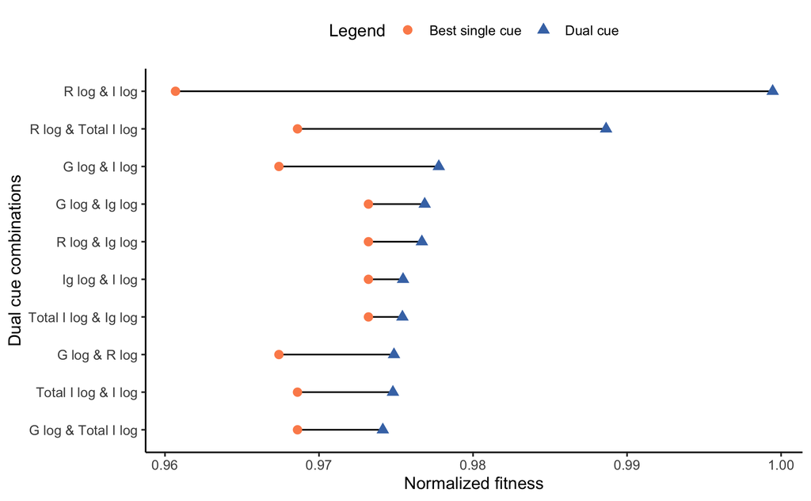

#————Time series conversion rate of dual cue models———–# Note that our dual cue models take 9 parameters. To ensure that any difference between dual and single cue models is due to the inclusion of additional cues and NOT higher spline flexibility,we performed L-BFGS-B (local) optimization of single cue models with df = 9 to control for the spline flexibility.

## dynamics simulation of high parameter cues

```r
## best dual cue model: I log and R log
Rlog_Ilog.cr <- chabaudi_si_clean(
  parameters_cr = c(6.875066649,    1.746121145,    0.678992033,    25.27235333,    -29.39793239,   -15.10449299,   43.5303092, -7.664658261,   11.64534955),
  immunity = "tsukushi",
  parameters = parameters_tsukushi,
  time_range = seq(0, 20, by = 1e-3),
  cue_range =  seq(6, 7, by = 1/500),
  cue_range_b = seq(0, log10(6*(10^6)), by = (log10(6*(10^6)))/500),
  cue = "R",
  cue_b = "I",
  log_cue = "log10",
  log_cue_b = "log10",
  solver = "vode",
  dyn = T
)
```

## plot

```r
time_high.cr
```

[output not shown]

#——– Reaction norm heatmap of R log10 + I log10 ————# # Process data

```r
# make heatmap data.frame
Rlog_Ilog.hm <- par_to_hm_te(par = c(6.875066649,   1.746121145,    0.678992033,    25.27235333,    -29.39793239,   -15.10449299,   43.5303092, -7.664658261,   11.64534955),
             cue_range = seq(6, 7, length.out = 500),
             cue_range_b = seq(0,   6.77815125, length.out = 500))

# process dynamics
Rlog_Ilog.dyn <- Rlog_Ilog.cr %>%
  tidyr::pivot_wider(names_from = variable, values_from = value) %>%
  mutate(log_R = log10(R),
         log_I = log10(I))
```